# The Effects of Booster on Weekly New Cases at the County Level in the U.S

Ming Zhao (919024805)

Mar 14, 2022

# Introduction

The omicron variant becomes the dominate strain of COVID-19 since December 2021, and it is more infectious than Delta among vaccinated and boosted people [(ref1)](https://www.health.com/condition/infectious-diseases/coronavirus/omicron-vs-delta). Plotting the global data from WHO in Figure 1, the new cases significantly increased due to the omicron variant from then on ([data1](https://covid19.who.int/)). In the worldwide growth, the U.S takes up the most cumulative cases, as shown in Figure 2. By further looking at the U.S. in Figure 3, the growth pattern is similar with the global. As the Figure 4 shows, the data at the state level also show a similar pattern ([data2](https://github.com/nytimes/covid-19-data)).

As a consequence, I am curious about whether vaccinations, specifically boosters, are still effective against infection in the U.S. This project focuses on the effects of booster rate on weekly new COVID-19 cases at the county level. The goal is to examine whether the percent of people who are fully vaccinated and have received a booster dose is associated with the most recent cases within the last 7 days. Linear regression and Negative Binomial Regression are the two methods proposed for studying the count data. Additionally, I include demographic features in the models, such as population density, race distribution, metro status. In the following, I first introduce the data I use, explore the data using descriptive statistics, fit models with diagnostics, and finally draw a conclusion.

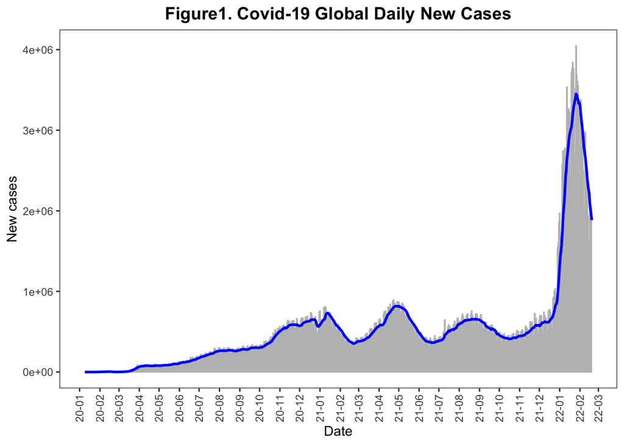

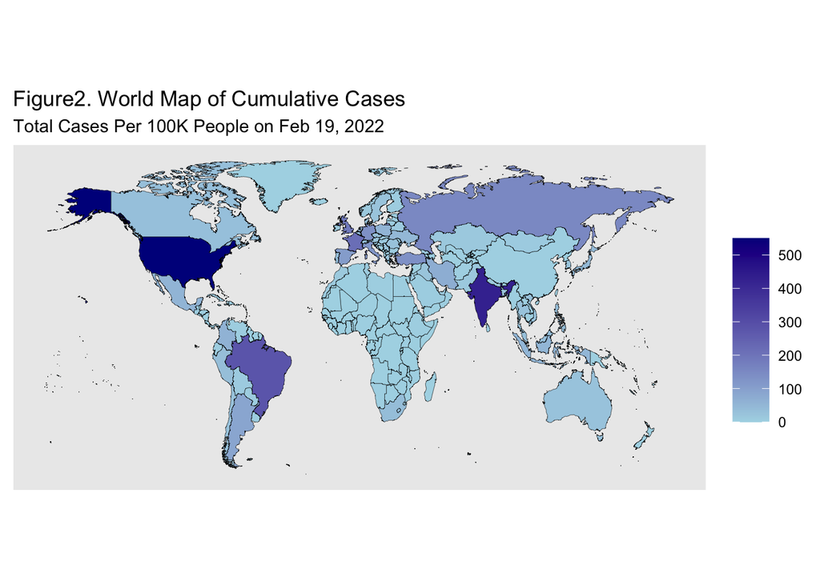

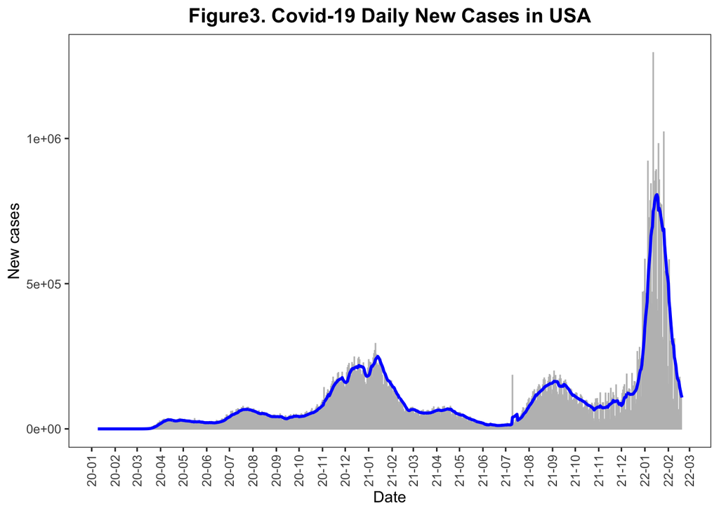

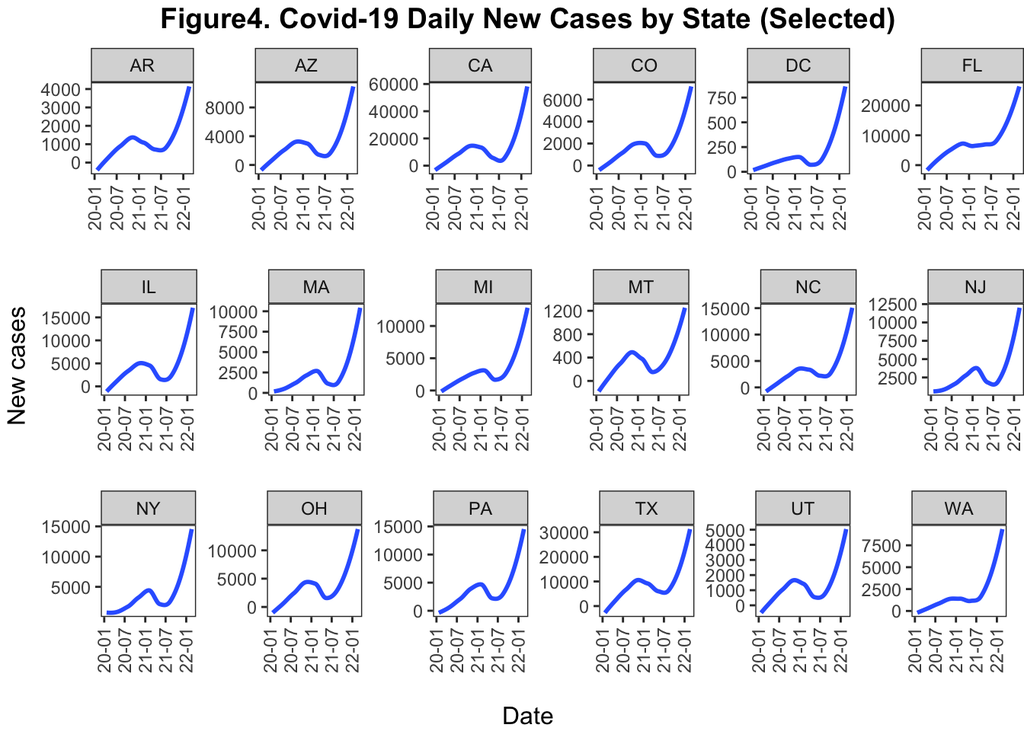

# Background

Figure 5 displays the cumulative cases by county and well shows the variation of infection among the counties ([data2](https://github.com/nytimes/covid-19-data)). In this project, I use the the U.S data at the county level. For the purpose of conducting the analysis, I first combine the case data ([data3](https://data.cdc.gov/Public-Health-Surveillance/United-States-COVID-19-County-Level-of-Community-T/nra9-vzzn)) and vaccination data ([data4](https://data.cdc.gov/Vaccinations/COVID-19-Vaccinations-in-the-United-States-County/8xkx-amqh)) from CDC. Then I collect demographic features about the counties: population density from Census ([data5](https://data.census.gov/cedsci/table?q=United%20States&t=-00%20-%20All%20available%20races&g=0100000US%240500000&tid=ACSSPP1Y2019.S0201)), race distribution, including Black percent, Hispanic percent, and Asian percent from Health Data ([data6](https://healthdata.gov/Health/COVID-19-Community-Profile-Report/gqxm-d9w9)). State and metro status are also added in the model and CDC provide such information in the vaccination data. Specifically, the outcome variable is weekly new cases defined as the total new cases from “2022-02-12” to “2022-02-19” per 100K people. The variable of interest is booster rate defined as the total number of people who are fully vaccinated and have received a booster shot divided by the total number of people who are fully vaccinated (have second dose of a two-dose vaccine or one dose of a single-dose vaccine), according to CDC ([ref2](https://data.cdc.gov/Vaccinations/COVID-19-Vaccinations-in-the-United-States-County/8xkx-amqh)).

The date of booster rate I use in the model is two week before the date of new cases, which is “2022-02-05” because it takes two weeks for booster to be effective ([ref3](https://www.health.com/condition/infectious-diseases/coronavirus/how-long-does-it-take-for-the-booster-to-be-effective)). My hypothesis is that although the omicron variant becomes dominant, the booster still works for its function. According to [Hill and Artiga](https://www.kff.org/coronavirus-covid-19/issue-brief/covid-19-cases-and-deaths-by-race-ethnicity-current-data-and-changes-over-time/), ethnicity minority is associated with more proportion of COVID-19 cases and deaths, so my hypothesis is that the more percent of Black, Hispanic, and Asian a county has, the more new cases the county has. For the population density, based on the study by [Wong and Li](https://journals.plos.org/plosone/article?id=10.1371/journal.pone.0242398), population density matters the COVID-19 cumulative cases at the county level to a certain extent, so my hypothesis is that, higher population density is positively associated with more new cases because I assume more contacts indicate more chance of infection, and it is similar for metro status.

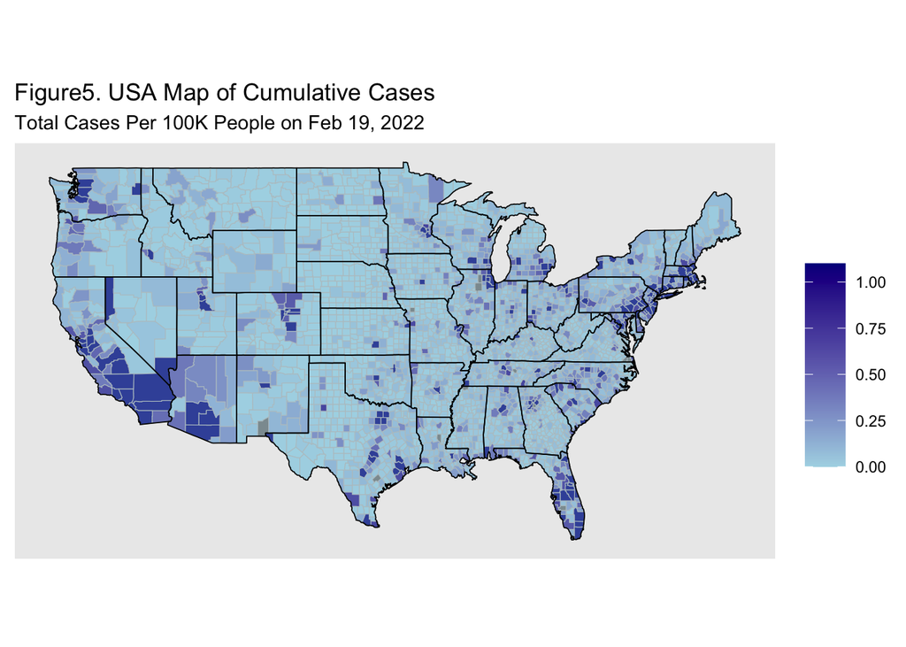

# Descriptive Analysis

#### Univariate Descriptive Statistics

Table1. Descriptive Statistics ($n=2761$)

| Quantitative Measures | Min | Mean | SD | Max |
| --- | --- | --- | --- | --- |
| New Cases | 0.00 | 333.95 | 324.51 | 5188.68 |
| Booster Rate | 0.00 | 40.26 | 10.42 | 70.00 |
| Black Percent | 0.00 | 0.09 | 0.14 | 0.86 |
| Hispanic Percent | 0.01 | 0.10 | 0.14 | 0.96 |
| Asian Percent | 0.00 | 0.02 | 0.03 | 0.43 |
| Population Density | 0.01 | 114.74 | 739.43 | 27819.80 |

Table2. Continued Descriptive Statistics ($n=2761$)

| Qualitative Measures | Level | N | % |
| --- | --- | --- | --- |
| Metro status | Metro | 1098 | 39.77 |
|  | Non-metro | 1663 | 60.23 |
| State | AK | 21 | 0.76 |
|  | AL | 65 | 2.35 |
|  | AR | 73 | 2.64 |
|  | AZ | 15 | 0.54 |
|  | CA | 58 | 2.10 |
|  | CO | 53 | 1.92 |
|  | CT | 8 | 0.29 |
|  | DC | 1 | 0.04 |
|  | DE | 3 | 0.11 |
|  | FL | 67 | 2.43 |
|  | GA | 136 | 4.93 |
|  | IA | 98 | 3.55 |
|  | ID | 36 | 1.30 |
|  | IL | 97 | 3.51 |
|  | IN | 90 | 3.26 |
|  | KS | 87 | 3.15 |
|  | KY | 119 | 4.31 |
|  | LA | 61 | 2.21 |
|  | MA | 11 | 0.40 |
|  | ME | 16 | 0.58 |
|  | MI | 81 | 2.93 |
|  | MN | 86 | 3.11 |
|  | MO | 112 | 4.06 |
|  | MS | 79 | 2.86 |
|  | MT | 37 | 1.34 |
|  | NC | 99 | 3.59 |
|  | ND | 28 | 1.01 |
|  | NH | 10 | 0.36 |
|  | NJ | 21 | 0.76 |
|  | NM | 32 | 1.16 |
|  | NV | 14 | 0.51 |
|  | NY | 61 | 2.21 |
|  | OH | 88 | 3.19 |
|  | OK | 70 | 2.54 |
|  | OR | 33 | 1.20 |
|  | PA | 65 | 2.35 |
|  | RI | 5 | 0.18 |
|  | SC | 46 | 1.67 |
|  | SD | 39 | 1.41 |
|  | TN | 95 | 3.44 |
|  | TX | 204 | 7.39 |
|  | UT | 18 | 0.65 |
|  | VA | 127 | 4.60 |
|  | VT | 14 | 0.51 |
|  | WA | 37 | 1.34 |
|  | WI | 70 | 2.54 |
|  | WV | 55 | 1.99 |
|  | WY | 20 | 0.72 |

#### Multivariate Descriptive Statistics

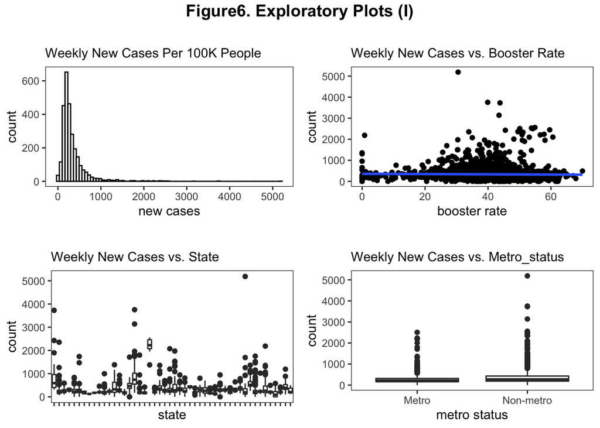

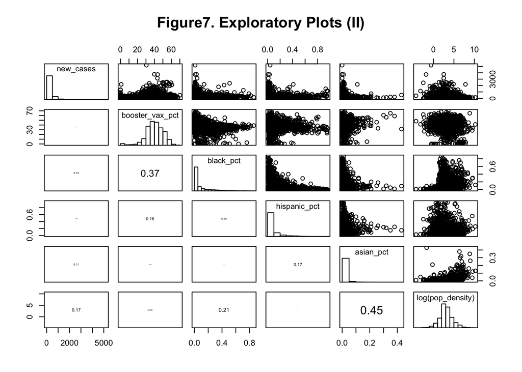

# Predictive Analysis

### Linear Regression

The question of interest in this project is to examine whether booster rate is related to weekly new cases. The proposed model for this question is multiple linear regression, which defined as:

$Y_i=\beta_0+\beta_1X_{i1}+\beta_2X_{i2}+\dots +\beta_pX_{ip}+\varepsilon_i \text{ , i=1,...,n}$

where $Y_i$ is the value of response variable in the ith case, $X_{i1}, \dots,X_{ip}$ are the values of the explanatory variables in the ith case, $\beta_0, \beta_1, \dots, \beta_p$ are regression coefficients, and $\varepsilon_i$ are random errors which are i.i.d. $N(0,\sigma^2)$. Here, p is the number of explanatory variables, and n is the sample size. The linear regression has four assumptions, 1) linearity of regression relation (the relationship between Xs and Y is linear), 2) normality of error terms (the model residuals are normally distributed), 3) constant variance of error terms (the residuals have equal variance), and 4) independence of error terms (the residuals are independent).

Specifically, in this project, $Y$ represents weekly new cases, $X_1, \dots,X_p$ are booster rate, Black percent, Hispanic percent, Asian percent, log-transformed population density, metro status, and state, respectively. For this method, I have two models:

$\text{ Model (1): }Y_i=\beta_0+\beta_1X_{i1}+\beta_7X_{i7}+\varepsilon_i \text{ , i=1,...,2761}$

$\text{ Model (2): }Y_i=\beta_0+\beta_1X_{i1}+\beta_2X_{i2}+\beta_3X_{i3}+\beta_4X_{i4}+\beta_5X_{i5}+\beta_6X_{i6}+\beta_7X_{i7}+\varepsilon_i \text{ , i=1,...,2761}$

where Model (1) is the reduced model and Model (2) is the full model. First, I test whether $X_{2},X_{3}, X_{4}, X_{5}, X_{6}$ may be dropped out from the full model. The null hypothesis (H0) is that all $\beta_2,\beta_3,\beta_4,\beta_5,\beta_6$ are equal to 0 and the alternative is that at least one of them is not 0. Based on the result shown in Table 3, p-value is 0, which is $< 0.05$, so H0 is rejected and conclude that the 5 variables should not be dropped from the full model. In addition, I do not test the interaction terms as I assume the effect of booster rate is not varied by state.

Next, I obtain ANOVA table for Model (2). The results in Table 4 show that the effect of booster rate were not significant if no variables were controlled. It is identical to the scatter plot in Figure 6 that there is no trend identified. However, when adding other explanatory variables, booster rate becomes significant.

Table3. ANOVA Test for Model (1) and (2)

| Res.Df | RSS | Df | Sum of Sq | F | Pr(>F) |
| --- | --- | --- | --- | --- | --- |
| 2712 | 162361389 |  |  |  |  |
| 2707 | 157704504 | 5 | 4656884 | 15.987 | 0 |

Table4. ANOVA Table for Model (2)

|  | Df | Sum Sq | Mean Sq | F value | Pr(>F) |
| --- | --- | --- | --- | --- | --- |
| Booster Rate | 1 | 110367.0 | 110367.04 | 1.894 | 0.169 |
| State | 47 | 128173295.1 | 2727091.38 | 46.811 | 0.000 |
| Black Percent | 1 | 914003.4 | 914003.40 | 15.689 | 0.000 |
| Hispanic Percent | 1 | 281061.4 | 281061.42 | 4.824 | 0.028 |
| Asian Percent | 1 | 1314261.2 | 1314261.16 | 22.559 | 0.000 |
| log(Population Density) | 1 | 1765715.6 | 1765715.60 | 30.309 | 0.000 |
| Metro Status | 1 | 381842.6 | 381842.61 | 6.554 | 0.011 |
| Residuals | 2707 | 157704504.5 | 58258.04 |  |  |

**Table5. Linear Regression Results**

|  | *Dependent variable:* |  |
| --- | --- | --- |
|  | Weekly New Cases |  |
|  | (1) | (2) |
| Booster Rate | -2.093*** | -1.632** |
|  | (0.736) | (0.747) |
| Black Percent |  | -136.986*** |
|  |  | (48.219) |
| Hispanic Percent |  | 160.975*** |
|  |  | (50.894) |
| Asian Percent |  | -290.385 |
|  |  | (226.111) |
| log(Population Density) |  | -16.876*** |
|  |  | (4.988) |
| Metro Status (ref = metro) |  | 30.992** |
|  |  | (12.106) |
| Constant | 996.173*** | 947.064*** |
|  | (62.178) | (63.710) |
| AIC | 38256.6 | 38186.3 |
| BIC | 38552.8 | 38512.1 |
| Observations | 2,761 | 2,761 |
| R<sup>2</sup> | 0.441 | 0.457 |
| *Note:* | p<0.1; p<0.05; p<0.01 |  |

Looking the diagnostic plots for Model (2) in Figure 8, the violation of model assumptions is observed. First, from the residuals vs fitted plot, we can see that the the relationship between outcome and predictors is not linear, and the residuals are not strictly constant. From the Q-Q plot, the normality of residuals are also violated. For these concerns, the results no long hold based on the parametric test. As a consequence, I perform a non-parametric permutation test for Model (2), which requires no distribution assumptions. The permutation test shows a consistent result in Table 6 that booster rate and other variables except Asian percent are significant.

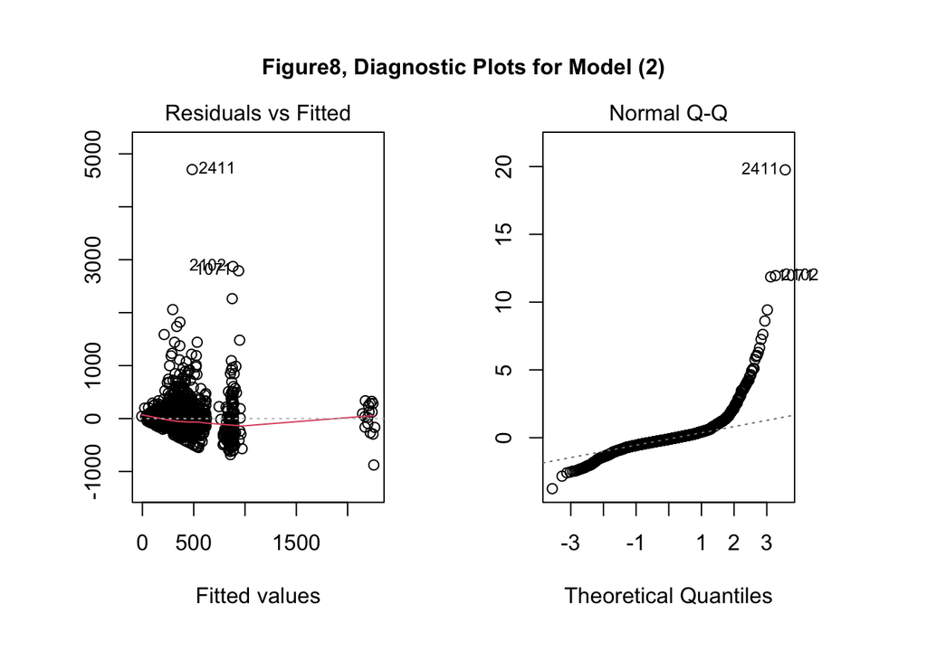

Table6. Permutation Test for Model (2)

|  | Df | R Sum Sq | R Mean Sq | Iter | Pr(Prob) |
| --- | --- | --- | --- | --- | --- |
| State | 47 | 118994173.17 | 2531790.92 | 5000 | 0.000 |
| Black Percent | 1 | 470184.44 | 470184.44 | 5000 | 0.000 |
| Hispanic Percent | 1 | 582815.83 | 582815.83 | 5000 | 0.000 |
| Asian Percent | 1 | 96085.69 | 96085.69 | 1274 | 0.073 |
| log(Population Density) | 1 | 666911.97 | 666911.97 | 5000 | 0.000 |
| Metro Status | 1 | 381842.61 | 381842.61 | 5000 | 0.000 |
| Booster Rate | 1 | 278076.21 | 278076.21 | 5000 | 0.000 |
| Residuals | 2707 | 157704504.46 | 58258.04 |  |  |

Therefore, the violation of normality can be reasonably ignored as the permutation test gives a consistent result. However, we still need to deal with the violation of linearity and unequal variance. As shown in Figure 6, the distribution of the outcome is right-skewed, which suggests that log-transformation on new cases may help to relieve the violation issues. Nevertheless, according to [O’Hara and Kotze](https://besjournals.onlinelibrary.wiley.com/doi/full/10.1111/j.2041-210X.2010.00021.x), log-transformation on discrete counts is not recommended because count data often contain many zero cases. That is, taking log-transformation on the original outcome will make the zero cases lost. In my situation, after transforming the new cases, I got an almost perfect normal distribution, but the price is losing all zero observations. I would like to keep all the samples, so I also tried taking log-transformation on (Y+1), but the model diagnostics looked even worse.

# Sensitivity Analysis

Poisson and Negative Binomial regression are two types of regression models for discrete count data. If the variance and mean are equal, Poisson regression is appropriate; if the variance is significantly larger than the mean, Negative Binomial regression is appropriate. First, I need to decide which method I should use. The overdispersion test shows that overdispersion is detected in Table 7 and there fore suggests Negative Binomial regression.

Table7. Overdispersion Test

| Dispersion ratio |  | = | 143.746 |
| --- | --- | --- | --- |
| Pearson’s Chi-Squared |  | = | 389838.435 |
| P-value |  | = | < 0.001 |
|  |  |  | Overdispersion detected |

### Negative Binomial Regression

With similar process as I performed for linear regression, I first define Model (3) with booster rate and state and Model (4) with all explanatory variables in the data set. As Table 8 shows, the full model is better than the reduced model as the p-value is 0. ANOVA table for the full model, Model (4), in Table 9, shows that without controlling for other variables, booster rate is only marginally significant. Table 10 displays the coefficients of Negative Binomial Regression. The overall results are consistent that Booster rate, Black percent, and log-transformed population density are negatively related to the new cases, Hispanic percent is positively, and Asian percent is not significantly. Also, non-metro is associated with more new cases than metro. Specifically, I am interested in the relationship between new cases and booster rate. The coefficient of booster rate is $-0.003$, so we can interpret it as the percent change in the incident rate of new cases is a 0.3% decrease for every unit increase in booster rate. Looking at the Figure 9, the assumptions of linearity and constant variance are reasonably held. For the normality, this assumption is still violated, but as the sample size is sufficiently large, normality assumption becomes not that important due to the Central Limit Theorem.

Table8. ANOVA Test for Model (3) and (4)

| Resid. df | 2 x log-lik. | Test | df | LR stat. | Pr(Chi) |
| --- | --- | --- | --- | --- | --- |
| 2712 | -35591.11 |  |  |  |  |
| 2707 | -35421.23 | 1 vs 2 | 5 | 169.8849 | 0 |

Table9. ANOVA Table for Model (4)

|  | Df | Deviance | Resid. Df | Resid. Dev | Pr(>Chi) |
| --- | --- | --- | --- | --- | --- |
| NULL |  |  | 2760 | 5373.251 |  |
| Booster Rate | 1 | 3.312 | 2759 | 5369.939 | 0.069 |
| State | 47 | 2134.524 | 2712 | 3235.415 | 0.000 |
| Black Percent | 1 | 25.303 | 2711 | 3210.112 | 0.000 |
| Hispanic Percent | 1 | 17.759 | 2710 | 3192.353 | 0.000 |
| Asian Percent | 1 | 43.626 | 2709 | 3148.728 | 0.000 |
| log(Population Density) | 1 | 81.127 | 2708 | 3067.600 | 0.000 |
| Metro Status | 1 | 7.288 | 2707 | 3060.312 | 0.007 |

**Table10. Negative Binomial Regression Results**

|  | *Dependent variable:* |  |
| --- | --- | --- |
|  | Weekly New Cases |  |
|  | (3) | (4) |
| Booster Rate | -0.004*** | -0.003** |
|  | (0.002) | (0.002) |
| Black Percent |  | -0.394*** |
|  |  | (0.110) |
| Hispanic Percent |  | 0.598*** |
|  |  | (0.116) |
| Asian Percent |  | -0.574 |
|  |  | (0.518) |
| log(Population Density) |  | -0.073*** |
|  |  | (0.011) |
| Metro Status (ref = metro) |  | 0.075*** |
|  |  | (0.028) |
| Constant | 7.003*** | 6.805*** |
|  | (0.144) | (0.145) |
| AIC | 35691.1 | 35531.2 |
| BIC | 35987.3 | 35857 |
| Observations | 2,761 | 2,761 |
| *Note:* | p<0.1; p<0.05; p<0.01 |  |

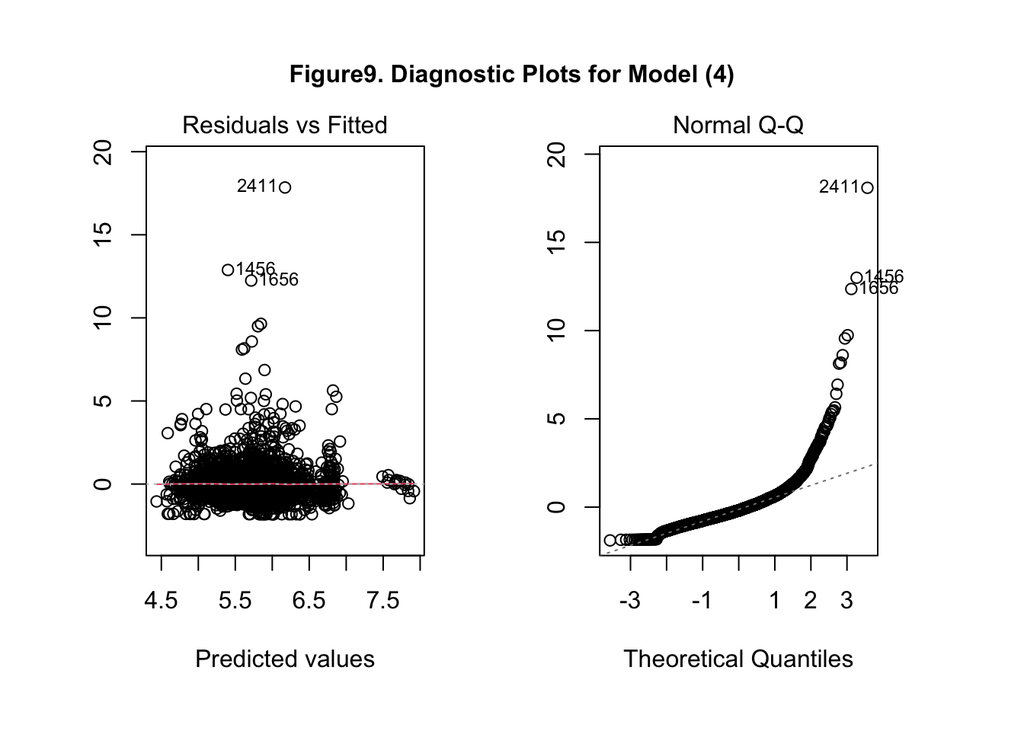

# Conclusion

Using Linear regression and Negative Binomial regression, I find that there is a significant negative effect of booster rate on weekly new cases at the county level in the U.S, when holding state, Black percent, Hispanic percent, log-transformed population density, and metro status constant. For the two methods, both of their normality assumption is violated. Although, the sample size is sufficiently large and the permutation test for the linear regression model suggests that it is not a issue, more test or techniques can be applied to deal with it or prove the validation. One of the caveats of this report is omitted variables. More demographic features can be included in the models. The results of the project shows that the booster is still effective against COVID-19, it may encourage people who are not boostered to have their booster dose on schedule.

# Appendix

https://github.com/mingzhao1103/sta207/blob/main/final_project_MingZhao.Rmd